# 时序数据分析-BAJAJFINSV股票走势预测

# 1、实验背景

时间序列分析是一种处理时间序列数据或趋势分析的统计技术。时间序列数据是指数据处于一系列特定的时间段或间隔内。数据可以分为三种类型：

- 时间序列数据：对变量在不同时间所取值的一组观察。
- 横截面数据：在同一时间，统计单位不同，统计指标相同的数据所组成的数据列。如：2020年各个国家的GDP
- 合并数据：时间序列数据和横截面数据的组合。

时间序列数据由四个部分组成，为了让这个概念更加清晰，这里对时间序列的各个组成部分进行了直观的解释：

- 趋势成分：这是一种在很长一段时间内以合理可预测的模式向上或向下移动的变化。
- 季节性成分：是有规律和周期性的变化，并在特定时间段内重复，例如一天、一周、一个月、一个季节等
- 周期性成分：是与商业或经济“繁荣-萧条”周期相对应或遵循其自身特殊周期的变化
- 随机扰动项：是不稳定或残差的变异，不属于上述三类中的任何一类。

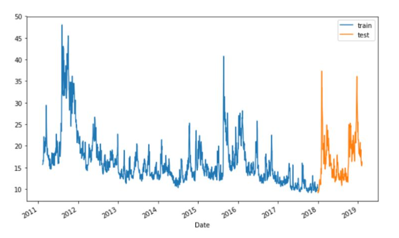

# 2、实验目标

- 了解常见的时间序列分析技术
- 运用时间序列分析技术进行股票分析
- 探索多个不同的分析模型并比较

# 3、实验总体设计

本实验首先对数据进行预处理，填补缺失值。接着进行特征工程，添加了一系列有意义的新特征（移动平均项）。接下来进行建模，分别使用了Auto ARIMAX、Prophet、LightGBM模型对股票数据进行拟合及预测，并将结果进行比对，选择出最优的模型。

本实验的另一现实意义是为解决时间序列问题提供一些更现代的算法/技术，并尝试将它们应用于股票市场数据以预测价格

# 4、实验详细实现步骤

## 4.1 安装必要工具包

- fbprophet包
- pmdarima包

fbprophet包和pmdarima包是时间序列建模中会用到的工具包，但是直接pip install来进行安装常常会报错，这里老师教大家如何去用另外一种方式来安装这两个包

**步骤：**

1、找到本实验文件同级文件夹下的 ”fbprophet、pmdarima包“文件夹，里面有四个文件，将其复制

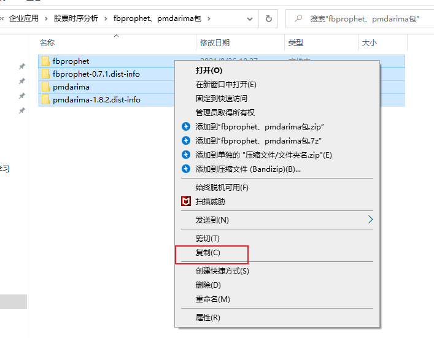

2、找到自己anaconda安装路径下的lib->sitepackages文件夹

我的路径是D:\conda\Lib\site-packages，大家根据自己具体的安装路径来定  
这个文件夹里面长这样，放着各种各样的包：

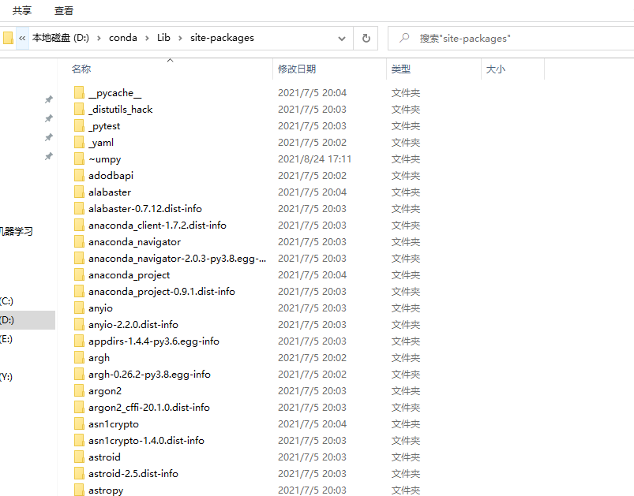

放的都是各种包

3、将刚刚复制的那四个文件夹粘贴到site-packages文件夹下

4、关闭并重启anaconda，大功告成，这两个包安装完毕

## 4.2 导入实验环境

```python
import numpy as np
import pandas as pd
import seaborn as sns
import matplotlib.pyplot as plt
sns.set(style='white')

import lightgbm as lgb
from fbprophet import Prophet
from pmdarima import auto_arima
from sklearn.metrics import mean_absolute_error, mean_squared_error

import warnings as wrn
wrn.filterwarnings('ignore', category = DeprecationWarning)
wrn.filterwarnings('ignore', category = FutureWarning)
wrn.filterwarnings('ignore', category = UserWarning)
```

## 4.3 数据准备

### 4.3.1 数据获取

```python
df = pd.read_csv("data/BAJAJFINSV.csv",parse_dates=["Date"],index_col="Date")
df.head()
```

| Date | Symbol | Series | Prev Close | Open | High | Low | Last | Close | VWAP | Volume | Turnover | Trades | Deliverable Volume | %Deliverble |
| --- | --- | --- | --- | --- | --- | --- | --- | --- | --- | --- | --- | --- | --- | --- |
| 2008-05-26 | BAJAJFINSV | EQ | 2101.05 | 600.00 | 619.00 | 501.0 | 505.1 | 509.10 | 548.85 | 3145446 | 1.726368e+14 | NaN | 908264 | 0.2888 |
| 2008-05-27 | BAJAJFINSV | EQ | 509.10 | 505.00 | 610.95 | 491.1 | 564.0 | 554.65 | 572.15 | 4349144 | 2.488370e+14 | NaN | 677627 | 0.1558 |
| 2008-05-28 | BAJAJFINSV | EQ | 554.65 | 564.00 | 665.60 | 564.0 | 643.0 | 640.95 | 618.37 | 4588759 | 2.837530e+14 | NaN | 774895 | 0.1689 |
| 2008-05-29 | BAJAJFINSV | EQ | 640.95 | 656.65 | 703.00 | 608.0 | 634.5 | 632.40 | 659.60 | 4522302 | 2.982921e+14 | NaN | 1006161 | 0.2225 |
| 2008-05-30 | BAJAJFINSV | EQ | 632.40 | 642.40 | 668.00 | 588.3 | 647.0 | 644.00 | 636.41 | 3057669 | 1.945929e+14 | NaN | 462832 | 0.1514 |

重要特征的解释：

```python
#查看数据维度
df.shape
```

```
(3201, 14)
```

```python
#数据整体信息
df.info()
```

```
<class 'pandas.core.frame.DataFrame'>
DatetimeIndex: 3201 entries, 2008-05-26 to 2021-04-30
Data columns (total 14 columns):
 #   Column              Non-Null Count  Dtype
---  ------              --------------  -----
 0   Symbol              3201 non-null   object
 1   Series              3201 non-null   object
 2   Prev Close          3201 non-null   float64
 3   Open                3201 non-null   float64
 4   High                3201 non-null   float64
 5   Low                 3201 non-null   float64
 6   Last                3201 non-null   float64
 7   Close               3201 non-null   float64
 8   VWAP                3201 non-null   float64
 9   Volume              3201 non-null   int64
 10  Turnover            3201 non-null   float64
 11  Trades              2456 non-null   float64
 12  Deliverable Volume  3201 non-null   int64
 13  %Deliverble         3201 non-null   float64
dtypes: float64(10), int64(2), object(2)
memory usage: 375.1+ KB
```

```python
#查看缺失值
df.isna().sum()
```

```
Symbol                  0
Series                  0
Prev Close              0
Open                    0
High                    0
Low                     0
Last                    0
Close                   0
VWAP                    0
Volume                  0
Turnover                0
Trades                745
Deliverable Volume      0
%Deliverble             0
dtype: int64
```

可以看到,大部分字段都没有缺失值,只有trades字段具有较大量的缺失值,因此我们首先需要对该列的缺失值进行处理

### 4.3.2 数据预处理

#### 4.3.2.1 删除缺失值

因为trades列包含的缺失值不是特别多，因此我们不用将其整列删除，我们这里使用的方法是将包含缺失值的行进行删除

```python
#删除缺失值
df.dropna(inplace=True)
df.isna().sum()
```

```
Symbol                0
Series                0
Prev Close            0
Open                  0
High                  0
Low                   0
Last                  0
Close                 0
VWAP                  0
Volume                0
Turnover              0
Trades                0
Deliverable Volume    0
%Deliverble           0
dtype: int64
```

可以看到，现在数据中没有缺失值了，接下来我们进行异常值的处理。

#### 4.3.2.2 处理异常值

首先进行异常值的检测：

```python
df.describe(percentiles=([.25,.50,.75,.99]))#显示25%，50%，75%，99%分位数
```

|  | Prev Close | Open | High | Low | Last | Close | VWAP | Volume | Turnover | Trades | Deliverable Volume | %Deliverble |
| --- | --- | --- | --- | --- | --- | --- | --- | --- | --- | --- | --- | --- |
| count | 2456.000000 | 2456.000000 | 2456.000000 | 2456.000000 | 2456.000000 | 2456.000000 | 2456.000000 | 2.456000e+03 | 2.456000e+03 | 2456.000000 | 2.456000e+03 | 2456.000000 |
| mean | 3478.457919 | 3484.883713 | 3538.150428 | 3430.660708 | 3482.948453 | 3482.742630 | 3485.558400 | 2.271266e+05 | 1.207884e+14 | 20892.811075 | 6.982322e+04 | 0.446229 |
| std | 2912.776647 | 2917.370667 | 2955.505811 | 2876.327523 | 2916.417287 | 2916.158528 | 2916.468838 | 3.542653e+05 | 2.420795e+14 | 32396.302068 | 1.025986e+05 | 0.208561 |
| min | 400.100000 | 340.000000 | 409.000000 | 340.000000 | 402.950000 | 400.100000 | 402.320000 | 3.472000e+03 | 1.472543e+11 | 149.000000 | 1.829000e+03 | 0.063700 |
| 25% | 818.225000 | 814.975000 | 831.425000 | 804.150000 | 818.800000 | 820.362500 | 818.545000 | 4.727975e+04 | 4.547649e+12 | 2951.750000 | 2.321000e+04 | 0.270275 |
| 50% | 1968.250000 | 1969.225000 | 1995.000000 | 1934.750000 | 1966.025000 | 1970.425000 | 1970.645000 | 1.123460e+05 | 2.651281e+13 | 9450.000000 | 4.441350e+04 | 0.434850 |
| 75% | 5819.112500 | 5815.750000 | 5914.425000 | 5700.000000 | 5833.075000 | 5822.425000 | 5816.335000 | 2.459470e+05 | 1.234519e+14 | 24439.750000 | 8.416575e+04 | 0.603425 |
| 99% | 9904.330000 | 9937.020000 | 10101.585000 | 9790.890000 | 9920.700000 | 9924.502500 | 9960.011000 | 1.708984e+06 | 1.179170e+15 | 163344.150000 | 4.030693e+05 | 0.917915 |
| max | 11176.550000 | 11000.000000 | 11300.000000 | 10868.700000 | 11175.450000 | 11176.550000 | 11081.780000 | 4.110412e+06 | 3.394379e+15 | 312959.000000 | 3.350588e+06 | 0.980400 |

**箱线图怎么看？**

箱线图常常用来做异常值的判断、数据集中趋势的观察、数据偏态的度量等等，下面是一个箱线图的实例：

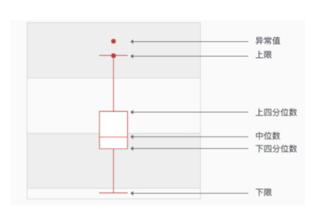

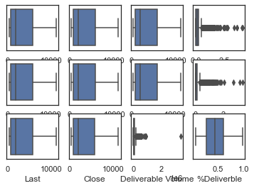

```python
#画出箱线图
#数据可视化中的箱线图常常用来判断异常值
import matplotlib.pyplot as plt
import seaborn as sns
#导入数据可视化包matplotlib,seaborn
fig,axes=plt.subplots(3,4)
#画出箱线图
sns.boxplot(x='Prev Close',data=df,ax=axes[0,0])
sns.boxplot(x='Open',data=df,ax=axes[0,1])
sns.boxplot(x='High',data=df,ax=axes[1,0])
sns.boxplot(x='Low',data=df,ax=axes[1,1])
sns.boxplot(x='Last',data=df,ax=axes[2,0])
sns.boxplot(x='Close',data=df,ax=axes[2,1])

sns.boxplot(x='VWAP',data=df,ax=axes[0,2])
sns.boxplot(x='Volume',data=df,ax=axes[0,3])#
sns.boxplot(x='High',data=df,ax=axes[1,2])
sns.boxplot(x='Turnover',data=df,ax=axes[1,3])#
sns.boxplot(x='Deliverable Volume',data=df,ax=axes[2,2])#
sns.boxplot(x='%Deliverble',data=df,ax=axes[2,3])
```

由箱线图可看出，Volume，Turnover和Deliverable Volume这三个指标存在异常值，需要进行处理。

异常值处理：

方法：根据3σ准则，数值分布在(μ-3σ,μ+3σ)中的概率为0.9974，所以对于超过这个区间的误差，就不属于随机误差而是粗大误差，含有该误差的数据应予以剔除。

```python
print(df.Volume.mean()-3*df.Volume.std(),df.Volume.mean()+3*df.Volume.std())
print(df.Turnover.mean()-3*df.Turnover.std(),df.Turnover.mean()+3*df.Turnover.std())
print(df['Deliverable Volume'].mean()-3*df['Deliverable Volume'].std(),df['Deliverable Volume'].mean()+3*df['Deliverable Volume'].std())
```

```
-835669.1924026059 1289922.3161811074
-605450257233646.4 847027036831052.6
-237972.68913721357 377619.121547637
```

```python
print(df.shape)
df=df[df.Volume<1289922.3161811074]
print(df.shape)
df=df[df.Turnover<847027036831052.6]
print(df.shape)
df=df[df['Deliverable Volume']<377619.121547637]
print(df.shape)
```

```
(2456, 14)
(2405, 14)
(2394, 14)
(2380, 14)
```

可见，数据量由原本的2456减小为2380，去除了76个异常值。

数据预处理准备完毕之后，接下来我们进行特征工程:

#### 4.3.2.2 特征工程

在时间序列问题中，我们常常会有一些外部特征或一些内部特征工程来帮助建立模型,这样的特征一般包含较多的信息量,对于提升模型效果有很大帮助。另外，由于我们需要预测一天的股票价格，我们不能使用同一天的特征值，因为它们在实际推理时是不可用的。我们需要使用统计数据，例如广泛用于时间序列问题的可用数字特征的滞后值，并取其均值，标准差等

```python
# 特征生成
df.reset_index(inplace=True)
lag_features = ["High", "Low", "Volume", "Turnover", "Trades"]#选择"High", "Low", "Volume", "Turnover", "Trades"这五个特征
window1 = 3
window2 = 7
window3 = 30

df_rolled_3d = df[lag_features].rolling(window=window1, min_periods=0)#三天的移动平均
df_rolled_7d = df[lag_features].rolling(window=window2, min_periods=0)#一周的移动平均
df_rolled_30d = df[lag_features].rolling(window=window3, min_periods=0)#一个月的移动平均

#取均值的移动平均
df_mean_3d = df_rolled_3d.mean().shift(1).reset_index().astype(np.float32)
df_mean_7d = df_rolled_7d.mean().shift(1).reset_index().astype(np.float32)
df_mean_30d = df_rolled_30d.mean().shift(1).reset_index().astype(np.float32)

#取标准差的移动平均
df_std_3d = df_rolled_3d.std().shift(1).reset_index().astype(np.float32)
df_std_7d = df_rolled_7d.std().shift(1).reset_index().astype(np.float32)
df_std_30d = df_rolled_30d.std().shift(1).reset_index().astype(np.float32)
```

函数介绍：

rolling函数是移动窗口函数

DataFrame.rolling(window, min_periods=None, freq=None, center=False, win_type=None, on=None, axis=0, closed=None) 参数：

- window：表示时间窗的大小，注意有两种形式（int or offset）。如果使用int，则数值表示计算统计量的观测值的数量即向前几个数据。如果是offset类型，表示时间窗的大小。
- min_periods：最少需要有值的观测点的数量，对于int类型，默认与window相等。对于offset类型，默认为1。
- freq：从0.18版本中已经被舍弃。
- center：是否使用window的中间值作为label，默认为false。只能在window是int时使用。

```python
for feature in lag_features:
    df[f"{feature}_mean_lag{window1}"] = df_mean_3d[feature]
    df[f"{feature}_mean_lag{window2}"] = df_mean_7d[feature]
    df[f"{feature}_mean_lag{window3}"] = df_mean_30d[feature]

    df[f"{feature}_std_lag{window1}"] = df_std_3d[feature]
    df[f"{feature}_std_lag{window2}"] = df_std_7d[feature]
    df[f"{feature}_std_lag{window3}"] = df_std_30d[feature]

df.fillna(df.mean(), inplace=True)
#因为是移动平均，在起始和末尾的地方会有空值，所以需要填补一下缺失值，我们使用均值来填补缺失值
```

接下来看一看加上了移动平均项之后的数据：

```python
# df.reset_index(inplace=True)
df.set_index("Date", drop=False, inplace=True)#既用时间列作为特征，又将该列作为索引

#对于boosting模型，添加日期时间特征（如小时、日、月）非常有用，适用于提供有关数据中时间组件的模型信息。
#对于时间序列模型，虽然没有明确要求提供此信息，但我们可以这样做，以便在完全相同的一组特征上比较所有模型。
df.head()
```

| Date | Date | Symbol | Series | Prev Close | Open | High | Low | Last | Close | VWAP | ... | Turnover_mean_lag30 | Turnover_std_lag3 | Turnover_std_lag7 | Turnover_std_lag30 | Trades_mean_lag3 | Trades_mean_lag7 | Trades_mean_lag30 | Trades_std_lag3 | Trades_std_lag7 | Trades_std_lag30 |
| --- | --- | --- | --- | --- | --- | --- | --- | --- | --- | --- | --- | --- | --- | --- | --- | --- | --- | --- | --- | --- | --- |
| 2011-06-01 | 2011-06-01 | BAJAJFINSV | EQ | 518.40 | 521.8 | 528.95 | 517.1 | 521.10 | 521.05 | 522.81 | ... | 8.999777e+13 | 2.684256e+13 | 3.242670e+13 | 3.961860e+13 | 17380.134766 | 17315.21875 | 17064.941406 | 5197.783203 | 6329.890625 | 8038.756836 |
| 2011-06-02 | 2011-06-02 | BAJAJFINSV | EQ | 521.05 | 518.8 | 519.85 | 504.0 | 514.95 | 512.45 | 513.71 | ... | 5.926609e+12 | 2.684256e+13 | 3.242670e+13 | 3.961860e+13 | 4155.000000 | 4155.00000 | 4155.000000 | 5197.783203 | 6329.890625 | 8038.756836 |
| 2011-06-03 | 2011-06-03 | BAJAJFINSV | EQ | 512.45 | 512.5 | 520.00 | 506.0 | 507.10 | 508.40 | 513.11 | ... | 4.580630e+12 | 1.903503e+12 | 1.903503e+12 | 1.903503e+12 | 3296.000000 | 3296.00000 | 3296.000000 | 1214.809448 | 1214.809448 | 1214.809448 |
| 2011-06-06 | 2011-06-06 | BAJAJFINSV | EQ | 508.40 | 508.0 | 508.00 | 496.0 | 502.25 | 502.25 | 501.92 | ... | 3.677100e+12 | 2.064161e+12 | 2.064161e+12 | 2.064161e+12 | 2782.000000 | 2782.00000 | 2782.000000 | 1237.121216 | 1237.121216 | 1237.121216 |
| 2011-06-07 | 2011-06-07 | BAJAJFINSV | EQ | 502.25 | 503.0 | 552.00 | 503.0 | 546.50 | 545.50 | 536.79 | ... | 3.178645e+12 | 8.469340e+11 | 1.958146e+12 | 1.958146e+12 | 1845.666626 | 2423.00000 | 2423.000000 | 551.246155 | 1239.288818 | 1239.288818 |

5 rows × 45 columns

```python
df.Date = pd.to_datetime(df.Date, format="%Y-%m-%d")
df["month"] = df.Date.dt.month
df["week"] = df.Date.dt.week
df["day"] = df.Date.dt.day
df["day_of_week"] = df.Date.dt.dayofweek
df.drop(['Deliverable Volume','%Deliverble'],axis=1,inplace=True)
df.head()
```

| Date | Date | Symbol | Series | Prev Close | Open | High | Low | Last | Close | VWAP | ... | Trades_mean_lag3 | Trades_mean_lag7 | Trades_mean_lag30 | Trades_std_lag3 | Trades_std_lag7 | Trades_std_lag30 | month | week | day | day_of_week |
| --- | --- | --- | --- | --- | --- | --- | --- | --- | --- | --- | --- | --- | --- | --- | --- | --- | --- | --- | --- | --- | --- |
| 2011-06-01 | 2011-06-01 | BAJAJFINSV | EQ | 518.40 | 521.8 | 528.95 | 517.1 | 521.10 | 521.05 | 522.81 | ... | 17380.134766 | 17315.21875 | 17064.941406 | 5197.783203 | 6329.890625 | 8038.756836 | 6 | 22 | 1 | 2 |
| 2011-06-02 | 2011-06-02 | BAJAJFINSV | EQ | 521.05 | 518.8 | 519.85 | 504.0 | 514.95 | 512.45 | 513.71 | ... | 4155.000000 | 4155.00000 | 4155.000000 | 5197.783203 | 6329.890625 | 8038.756836 | 6 | 22 | 2 | 3 |
| 2011-06-03 | 2011-06-03 | BAJAJFINSV | EQ | 512.45 | 512.5 | 520.00 | 506.0 | 507.10 | 508.40 | 513.11 | ... | 3296.000000 | 3296.00000 | 3296.000000 | 1214.809448 | 1214.809448 | 1214.809448 | 6 | 22 | 3 | 4 |
| 2011-06-06 | 2011-06-06 | BAJAJFINSV | EQ | 508.40 | 508.0 | 508.00 | 496.0 | 502.25 | 502.25 | 501.92 | ... | 2782.000000 | 2782.00000 | 2782.000000 | 1237.121216 | 1237.121216 | 1237.121216 | 6 | 23 | 6 | 0 |
| 2011-06-07 | 2011-06-07 | BAJAJFINSV | EQ | 502.25 | 503.0 | 552.00 | 503.0 | 546.50 | 545.50 | 536.79 | ... | 1845.666626 | 2423.00000 | 2423.000000 | 551.246155 | 1239.288818 | 1239.288818 | 6 | 23 | 7 | 1 |

5 rows × 47 columns

```python
df_train = df[df.Date < "2018"]
df_valid = df[df.Date >= "2018"]

exogenous_features = ["High_mean_lag3", "High_std_lag3", "Low_mean_lag3", "Low_std_lag3",
                      "Volume_mean_lag3", "Volume_std_lag3", "Turnover_mean_lag3",
                      "Turnover_std_lag3", "Trades_mean_lag3", "Trades_std_lag3",
                      "High_mean_lag7", "High_std_lag7", "Low_mean_lag7", "Low_std_lag7",
                      "Volume_mean_lag7", "Volume_std_lag7", "Turnover_mean_lag7",
                      "Turnover_std_lag7", "Trades_mean_lag7", "Trades_std_lag7",
                      "High_mean_lag30", "High_std_lag30", "Low_mean_lag30", "Low_std_lag30",
                      "Volume_mean_lag30", "Volume_std_lag30", "Turnover_mean_lag30",
                      "Turnover_std_lag30", "Trades_mean_lag30", "Trades_std_lag30",
                      "month", "week", "day", "day_of_week"]
```

## 4.4 模型对比

在本节中，我们分别使用ARIMA模型、Prophet模型以及LightGBM模型来对股票时序数据进行拟合以及预测，并且将预测的效果进行对比，判断使用哪种方法来进行拟合的效果最好。

- ARIMA模型
- Prophet模型
- LightGBM模型

### 4.4.1 Auto ARIMAX

ARIMA模型根据给定的时间序列自身的过去值，即其自身的滞后和滞后的预测误差来解释给定的时间序列，因此该模型可用于预测未来值。

ARIMA模型需要某些输入参数：p代表 AR（p)（自回归项），q代表MA(q)（移动平均），d代表I(d)（差分）。值得庆幸的是，有一个可以自动选择这些参数的模型，被称为Auto ARIMA。

```python
#构建模型
model = auto_arima(df_train.VWAP, exogenous=df_train[exogenous_features], trace=True, error_action="ignore", suppress_warnings=True)#
#模型训练
model.fit(df_train.VWAP, exogenous=df_train[exogenous_features])
```

```
Performing stepwise search to minimize aic
 ARIMA(2,0,2)(0,0,0)[0] intercept   : AIC=21621.832, Time=3.71 sec
 ARIMA(0,0,0)(0,0,0)[0] intercept   : AIC=19132.164, Time=2.49 sec
 ARIMA(1,0,0)(0,0,0)[0] intercept   : AIC=20541.539, Time=2.50 sec
 ARIMA(0,0,1)(0,0,0)[0] intercept   : AIC=21641.235, Time=3.23 sec
 ARIMA(0,0,0)(0,0,0)[0]             : AIC=29468.932, Time=2.36 sec
 ARIMA(1,0,1)(0,0,0)[0] intercept   : AIC=21552.037, Time=3.34 sec

Best model:  ARIMA(0,0,0)(0,0,0)[0] intercept
Total fit time: 17.655 seconds
```

```
ARIMA(order=(0, 0, 0), scoring_args={}, suppress_warnings=True)
```

```python
auto_arima?
```

**auto_arima函数解释**：

auto_arima(y, exogenous=None, start_p=2, d=None, start_q=2, max_p=5, max_d=2, max_q=5, start_P=1, D=None, start_Q=1, max_P=2, max_D=1, max_Q=2, max_order=10, m=1, seasonal=True, stationary=False, information_criterion=‘aic’, alpha=0.05, test=‘kpss’, seasonal_test=‘ch’, stepwise=True, n_jobs=1, start_params=None, trend=‘c’, method=None, transparams=True, solver=‘lbfgs’, maxiter=50, disp=0, callback=None, offset_test_args=None, seasonal_test_args=None, suppress_warnings=False, error_action=‘warn’, trace=False, random=False, random_state=None, n_fits=10, return_valid_fits=False, out_of_sample_size=0, scoring=‘mse’, scoring_args=None, **fit_args)

重要参数解释：

y : 要拟合的时间序列，需要是一维的浮点型数组。不能包含‘np.nan’ 或者‘np.inf’；

exogenous : 可以在给定时间序列数据之外，给定额外的特征来帮助预测，需要注意的是，对于预测未来的时序数据的时候，也要提供未来的特征数据。

start_p : int, 默认2，算法自动选择p时的下界。

d : int, 默认None,非周期的差分阶数，如果是None，则自动选择，此时，运行时间会显著增加。

start_q : int, 默认2，算法自动选择q时的下界。

max_p : int, 默认5，算法自动选择p时的上界，必须≥start_p。

max_d : int, 默认2，算法自动选择d（非周期差分阶数）时的上界，必须≥d。

max_q : int, 默认5，算法自动选择q时的上界，必须≥start_q。

start_P : int,默认1，周期模型自动选择P时的下界。

```python
#模型预测
forecast = model.predict(n_periods=len(df_valid),exogenous=df_valid[exogenous_features])
df_valid["Forecast_ARIMAX"] = forecast
```

```python
#模型评估
print("RMSE of Auto ARIMAX:", np.sqrt(mean_squared_error(df_valid.VWAP, df_valid.Forecast_ARIMAX)))
print("\nMAE of Auto ARIMAX:", mean_absolute_error(df_valid.VWAP, df_valid.Forecast_ARIMAX))
#分别使用均方根误差 RMSE和平均绝对误差MAE来进行评估
```

```
RMSE of Auto ARIMAX: 375.9923438572707

MAE of Auto ARIMAX: 258.99316003421643
```

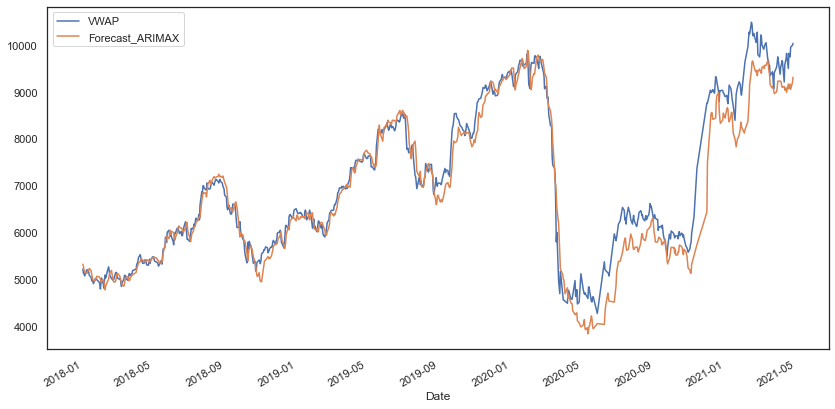

```python
#模型可视化
df_valid[["VWAP", "Forecast_ARIMAX"]].plot(figsize=(14, 7))
```

【结果分析】

Auto ARIMAX 模型在根据前一天的数据预测股票价格方面似乎做得相当好。其他模型能打败它吗？

### 4.4.2 Prophet模型

Prophet 是 Facebook 开发的开源时间序列模型。它于 2017 年初发布。 摘自主页：

> Prophet 是一种基于可加模型预测时间序列数据的程序，其中非线性趋势与每年、每周和每天的季节性以及假日效应相吻合。它最适用于具有强烈季节性影响和多个季节历史数据的时间序列。Prophet 对缺失数据和趋势变化具有稳健性，并且通常可以很好地处理异常值。

Prophet遵循 sklearn 模型的API。我们创建了一个Prophet类的实例，然后调用它的fit和predict方法。

Prophet的输入始终是具有两列的数据框：ds 和 y。ds (datestamp) 列应该是Pandas期望的格式，最好是 YYYY-MM-DD 表示日期或 YYYY-MM-DD HH:MM:SS 表示时间戳。y 列必须是数字，表示我们希望预测的度量。

```python
#模型实例化
model_fbp = Prophet()
for feature in exogenous_features:
    model_fbp.add_regressor(feature)
#训练模型
model_fbp.fit(df_train[["Date", "VWAP"] + exogenous_features].rename(columns={"Date": "ds", "VWAP": "y"}))
#模型预测
forecast = model_fbp.predict(df_valid[["Date", "VWAP"] + exogenous_features].rename(columns={"Date": "ds"}))
df_valid["Forecast_Prophet"] = forecast.yhat.values
```

```
INFO:fbprophet:Disabling daily seasonality. Run prophet with daily_seasonality=True to override this.
A value is trying to be set on a copy of a slice from a DataFrame.
Try using .loc[row_indexer,col_indexer] = value instead

See the caveats in the documentation: https://pandas.pydata.org/pandas-docs/stable/user_guide/indexing.html#returning-a-view-versus-a-copy
  df_valid["Forecast_Prophet"] = forecast.yhat.values
```

```python
#模型评估
print("RMSE of Auto ARIMAX:", np.sqrt(mean_squared_error(df_valid.VWAP, df_valid.Forecast_ARIMAX)))
print("RMSE of Prophet:", np.sqrt(mean_squared_error(df_valid.VWAP, df_valid.Forecast_Prophet)))
print("\nMAE of Auto ARIMAX:", mean_absolute_error(df_valid.VWAP, df_valid.Forecast_ARIMAX))
print("MAE of Prophet:", mean_absolute_error(df_valid.VWAP, df_valid.Forecast_Prophet))
```

```
RMSE of Auto ARIMAX: 375.9923438572707
RMSE of Prophet: 1387.829972898888

MAE of Auto ARIMAX: 258.99316003421643
MAE of Prophet: 1019.1045525803902
```

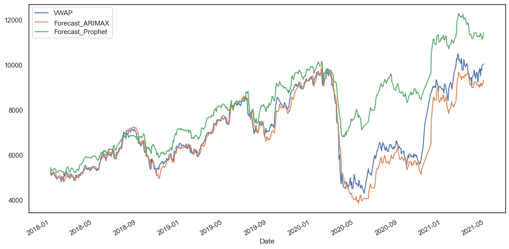

```python
#模型可视化
df_valid[["VWAP", "Forecast_ARIMAX", "Forecast_Prophet"]].plot(figsize=(14, 7))
```

【结果分析】

可以看到，拟合的效果较为一般，在这种情况下，Auto ARIMAX 的性能优于 Prophet。

### 4.4.3 LightGBM模型

时间序列问题通常被转换为表格结构，并输入到LightGBM和XGBoost等增强模型中。这里我们使用lightgbm来进行尝试

**Lightgbm:**

> LightGBM是微软旗下的Distributed Machine Learning Toolkit （DMKT）的一个项目，由2014年首届阿里巴巴大数据竞赛获胜者之一柯国霖主持开发。虽然其开源时间才仅仅2个月，但是其快速高效的特点已经在数据科学竞赛中崭露头角。Allstate Claims Severity竞赛中的冠军解决方案里就使用了LightGBM

lightgbm常用函数：

1、lgb.Dataset()  
即构建数据集，用于后面的模型训练 lgb.Dataset(data, label=label, feature_name=['c1', 'c2', 'c3'], categorical_feature=['c3'], weight=w )

2、lgb.train() 进行训练  
lgb.train(params,lgb_train,num_boost_round=20,valid_sets=lgb_eval,early_stopping_rounds=5)

3、训练数据需要参数列表和数据集，其中参数列表为：

params = { 'task': 'train',  
'boosting_type': 'gbdt', # 设置提升类型  
'objective': 'regression', # 目标函数  
'metric': {'l2', 'auc'}, # 评估函数  
'num_leaves': 31, # 叶子节点数  
'learning_rate': 0.05, # 学习速率  
'feature_fraction': 0.9, # 建树的特征选择比例  
'bagging_fraction': 0.8, # 建树的样本采样比例  
'bagging_freq': 5, # k 意味着每 k 次迭代执行bagging  
'verbose': 1 # <0 显示致命的, =0 显示错误 (警告), >0 显示信息  
}

4、进行预测  
gbm.predict(X_test, num_iteration=gbm.best_iteration)  
如果在训练期间启用了早期停止，可以通过best_iteration方式从最佳迭代中获得预测

5、模型评估  
print('The rmse of prediction is:', mean_squared_error(y_test, y_pred) ** 0.5)  
计算真实值和预测值之间的均方根误差

请注意，本实验使用默认参数，后续可以调整它们以改善结果。

```python
#数据准备
params = {"objective": "regression"}
dtrain = lgb.Dataset(df_train[exogenous_features], label=df_train.VWAP.values)
dvalid = lgb.Dataset(df_valid[exogenous_features])
#模型训练
model_lgb = lgb.train(params, train_set=dtrain)
#模型预测
forecast = model_lgb.predict(df_valid[exogenous_features])
df_valid["Forecast_LightGBM"] = forecast
```

```
[LightGBM] [Warning] Auto-choosing row-wise multi-threading, the overhead of testing was 0.014612 seconds.
You can set `force_row_wise=true` to remove the overhead.
And if memory is not enough, you can set `force_col_wise=true`.
[LightGBM] [Info] Total Bins 7756
[LightGBM] [Info] Number of data points in the train set: 1618, number of used features: 34
[LightGBM] [Info] Start training from score 1703.428893
```

```python
#模型评估
print("RMSE of Auto ARIMAX:", np.sqrt(mean_squared_error(df_valid.VWAP, df_valid.Forecast_ARIMAX)))
print("RMSE of Prophet:", np.sqrt(mean_squared_error(df_valid.VWAP, df_valid.Forecast_Prophet)))
print("RMSE of LightGBM:", np.sqrt(mean_squared_error(df_valid.VWAP, df_valid.Forecast_LightGBM)))
print("\nMAE of Auto ARIMAX:", mean_absolute_error(df_valid.VWAP, df_valid.Forecast_ARIMAX))
print("MAE of Prophet:", mean_absolute_error(df_valid.VWAP, df_valid.Forecast_Prophet))
print("MAE of LightGBM:", mean_absolute_error(df_valid.VWAP, df_valid.Forecast_LightGBM))
```

```
RMSE of Auto ARIMAX: 375.9923438572707
RMSE of Prophet: 1387.829972898888
RMSE of LightGBM: 2666.2639728892063

MAE of Auto ARIMAX: 258.99316003421643
MAE of Prophet: 1019.1045525803902
MAE of LightGBM: 2108.4783845914717
```

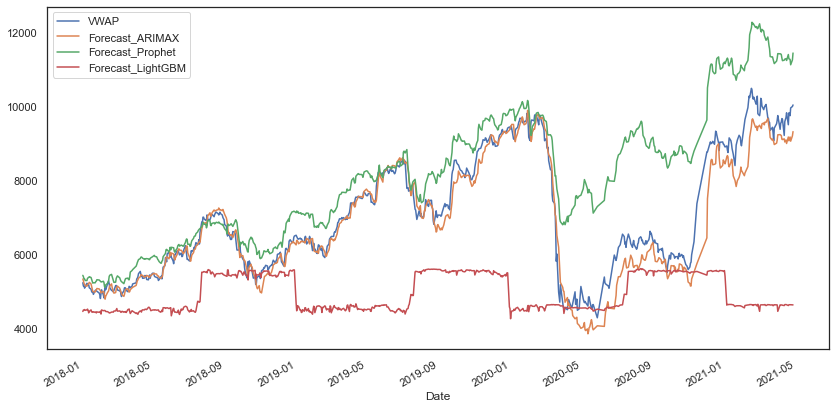

```python
#模型可视化对比
df_valid[["VWAP", "Forecast_ARIMAX", "Forecast_Prophet", "Forecast_LightGBM"]].plot(figsize=(14, 7))
```

【结果分析】

LightGBM 的表现非常差！请记住，boosting模型的预测范围仅限于在训练数据中出现的目标值范围,这是对时间序列使用boosting模型的一个关键的问题。

那么为什么boosting方法仍然如此流行呢？因为boosting模型仅在数据趋势非常强的情况下表现不佳。股票价格就是一个例子，它通常具有很强的趋势，在其他情况下，boosting模型的效果都非常好

# 5、总结分析

本实验中，我们使用分别使用Auto ARIMAX、Prophet、LightGBM模型对股票数据进行拟合及预测，主要要点如下：